# Randomly Perturb Some Parameter Value with Varying Magnitudes

[Fan Wang](https://fanwangecon.github.io/)

2021-07-06

# 1 Randomly Perturbing a Parameter

> Go to the [**RMD**](https://github.com/FanWangEcon//R4Econ/blob/master/statistics/random//fs_perturb_parameter.Rmd), [**R**](https://github.com/FanWangEcon//R4Econ/blob/master/statistics/random//htmlpdfr/fs_perturb_parameter.R), [**PDF**](https://github.com/FanWangEcon//R4Econ/blob/master/statistics/random//htmlpdfr/fs_perturb_parameter.pdf), or [**HTML**](https://fanwangecon.github.io//R4Econ/statistics/random//htmlpdfr/fs_perturb_parameter.html) version of this file. Go back to [fan](http://fanwangecon.github.io/)’s [REconTools](https://fanwangecon.github.io/REconTools/) Package, [R Code Examples](https://fanwangecon.github.io/R4Econ/) Repository ([bookdown site](https://fanwangecon.github.io/R4Econ/bookdown)), or [Intro Stats with R](https://fanwangecon.github.io/Stat4Econ/) Repository ([bookdown site](https://fanwangecon.github.io/Stat4Econ/bookdown)).

## 1.1 Perturbation Normally with Log-Normal Magnitude Scaling Value

During estimation, we have some starting estimation parameter value. We want to do multi-start estimation by perturbing initial starting points. The perturbing process follows the rules specified below, implemented in the function below.

1. Select from 0 to 1, 0 closest to the existing parameter value, 1 very far from it.
2. Log normal distribution with 1st quartile = 0.185, and mu of normal = 0. The value from (1) correspond to a cumulative mass point of this log normal distribution.
3. Draw a value randomly from standard normal
4. Transform the randomly drawn value to current parameter scale with inverse z-score, the resulting value is the parameter of interest.

Test and implement the ideas above.

```r
# Step 0
ar_fl_original_param <- c(-100, -10, -1, -0.1, 0, 0.1, 1, 10, 100)
ar_fl_original_param <- c(-10, -0.1, 0, 0.1, 10)
# Step 1
ar_zero_to_one_select <- seq(1e-3, 1 - 1e-3, length.out = 11)
# Step 2
# Assume mean of normal = 0, with sdlog = 2, 25th percentile is 0.185
fl_sdlog <- 2.5
fl_p25_logn <- qlnorm(0.25, meanlog = 0, sdlog = fl_sdlog)
# Step 3
# random draw, for now fix at positive number, which means to "randomly" expand
fl_draw_znorm <- 1
# Step 4
mt_collect <- matrix(
  data = NA,
  nrow = length(ar_zero_to_one_select),
  ncol = length(ar_fl_original_param)
)
it_col_ctr <- 0
for (fl_original_param in ar_fl_original_param) {
  it_col_ctr <- it_col_ctr + 1
  # inverse z-score
  ar_logn_coef_of_var <- qlnorm(1-ar_zero_to_one_select, meanlog = 0, sdlog = fl_sdlog)
  ar_logn_sd <- fl_original_param/ar_logn_coef_of_var
  ar_param_perturbed <- fl_draw_znorm * ar_logn_sd + fl_original_param
  # fill matrix
  mt_collect[, it_col_ctr] <- (ar_param_perturbed)
}
# Out to table
ar_st_varnames <- c("zero_one_scalar", paste0("ori_val=", ar_fl_original_param))
# Combine to tibble, add name col1, col2, etc.
tb_collect <- as_tibble(cbind(ar_zero_to_one_select, mt_collect)) %>%
  rename_all(~ c(ar_st_varnames))
# Display
kable(tb_collect) %>% kable_styling_fc()
```

| zero_one_scalar | ori_val=-10 | ori_val=-0.1 | ori_val=0 | ori_val=0.1 | ori_val=10 |
| --- | --- | --- | --- | --- | --- |
| 0.0010 | -10.00441 | -0.1000441 | 0 | 0.1000441 | 10.00441 |
| 0.1008 | -10.41068 | -0.1041068 | 0 | 0.1041068 | 10.41068 |
| 0.2006 | -11.22616 | -0.1122616 | 0 | 0.1122616 | 11.22616 |
| 0.3004 | -12.70326 | -0.1270326 | 0 | 0.1270326 | 12.70326 |
| 0.4002 | -15.31489 | -0.1531489 | 0 | 0.1531489 | 15.31489 |
| 0.5000 | -20.00000 | -0.2000000 | 0 | 0.2000000 | 20.00000 |
| 0.5998 | -28.81508 | -0.2881508 | 0 | 0.2881508 | 28.81508 |
| 0.6996 | -46.99235 | -0.4699235 | 0 | 0.4699235 | 46.99235 |
| 0.7994 | -91.55561 | -0.9155561 | 0 | 0.9155561 | 91.55561 |
| 0.8992 | -253.49612 | -2.5349612 | 0 | 2.5349612 | 253.49612 |
| 0.9990 | -22665.67969 | -226.6567969 | 0 | 226.6567969 | 22665.67969 |

Implement the above idea with a function.

```r
ffi_param_logn_perturber <- function(
  param_original=5, scaler_0t1=0.5,
  it_rand_seed=1, fl_sdlog=2.5, fl_min_quantile=1e-3) {
  #' @param float original current parameter value to be perturbed
  #' @param scaler_0t1 float, must be between 0 to 1, 0 means don't scale much, 1 mean a lot
  #' @param it_rand_seed integer randomly sperturbing seed
  #' @param fl_sdlog float the sdlog parameter
  #' @param fl_min_quantile float minimum quantile point (and 1 - max) to allow for selecting 0 and 1 for scalar_0t1

  # Draw randomly
  set.seed(it_rand_seed)
  fl_draw_znorm <- rnorm(1)
  # logn value at quantile
  scaler_0t1 <- scaler_0t1*(1-fl_min_quantile*2) + fl_min_quantile
  logn_coef_of_var <- qlnorm(1-scaler_0t1, meanlog = 0, sdlog = fl_sdlog)
  # Coefficient of variation
  ar_logn_sd <- param_original/logn_coef_of_var
  # Invert z-score
  param_perturbed <- fl_draw_znorm * ar_logn_sd + param_original

  return(param_perturbed)
}
```

Test the function with differently randomly drawn parameters, and visualize.

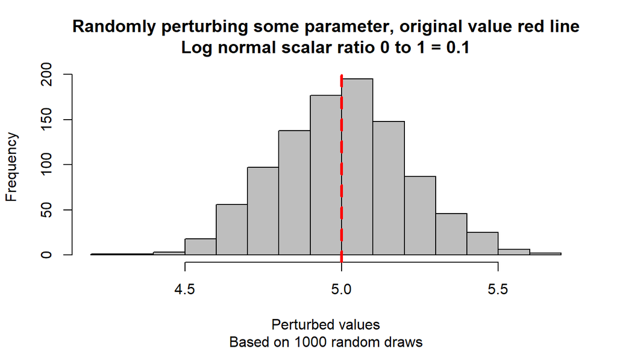

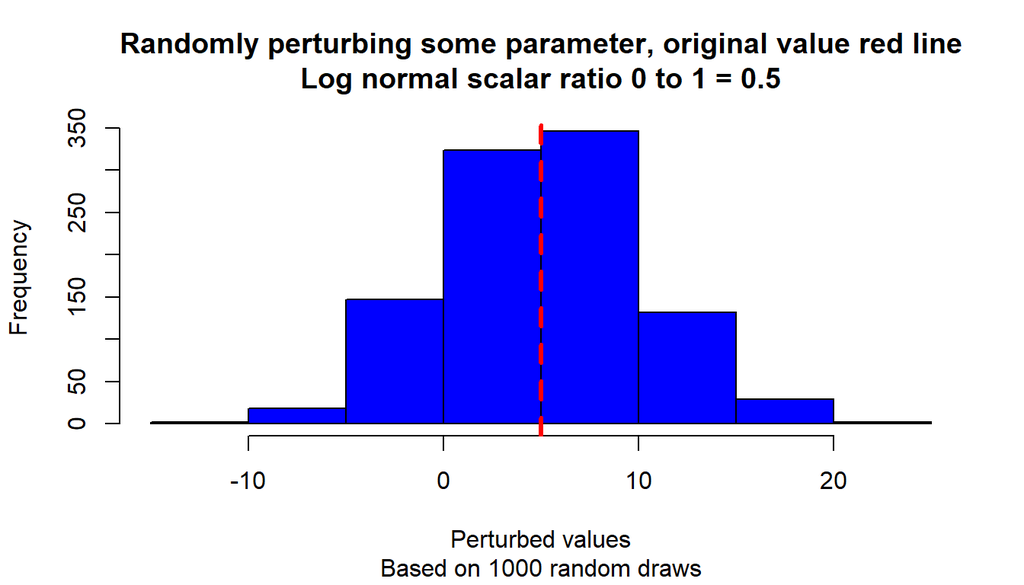

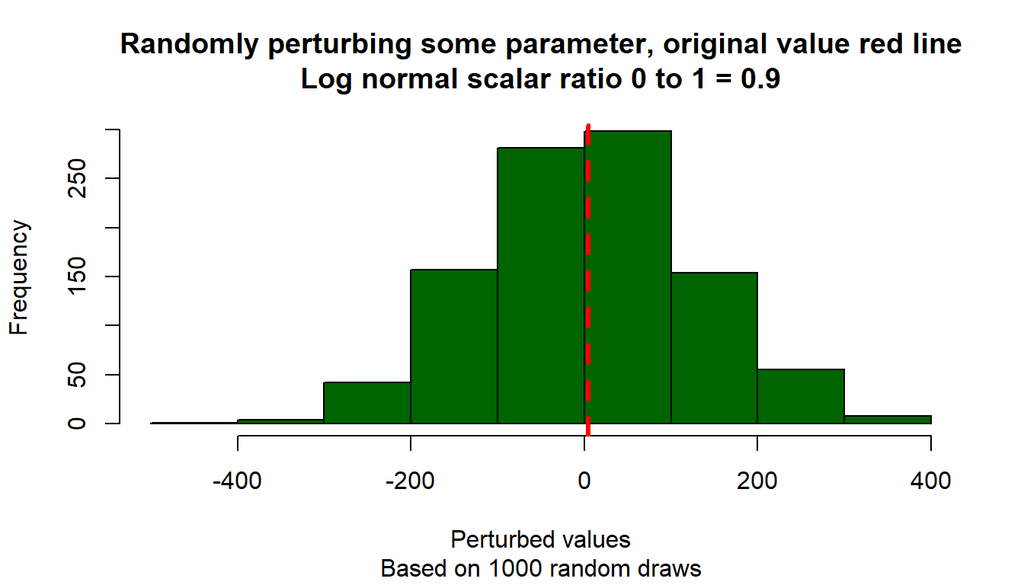

```r
# Start image
# Loop over different scalars
param_original <- 5
ar_scaler_0t1 <- c(0.1, 0.5, 0.9)
ar_color_strs <- c("gray", "blue", "darkgreen")
it_scalar_ctr <- 0
for (scaler_0t1 in ar_scaler_0t1) {
  it_scalar_ctr <- it_scalar_ctr + 1

  # Generate differently perturbed parameters
  ar_param_perturbed <- c()
  for (it_rand_seed in seq(1, 1000)) {
    param_perturbed <- ffi_param_logn_perturber(
      param_original, scaler_0t1, it_rand_seed=it_rand_seed)
    ar_param_perturbed <- c(ar_param_perturbed, param_perturbed)
  }

  # Line through origin
  par(mfrow = c(1, 1))
  hist(ar_param_perturbed, col = ar_color_strs[it_scalar_ctr],
       ylab = "", xlab = "", main = "")
  # Original parameter line
  abline(
    v = param_original,
    col = "red", lwd = 3, lty = 2
  )
  # Titles
  title(
    main = paste0(
      "Randomly perturbing some parameter, original value red line\n",
      "Log normal scalar ratio 0 to 1 = ", scaler_0t1
    ),
    sub = paste0(
      "Based on 1000 random draws"
    ),
    xlab = "Perturbed values", ylab = "Frequency"
  )
}
```